# ProbBreed in Practice

A Hands-On Tutorial for Cultivar Recommendation in Multi-Environment Trials

Authors

Wagner Faria Barbosa

Rhoda Ayanfeoluwa Ojo

Published

August 20, 2026

# 1 Introduction

This tutorial is the practical companion to our talk on the `ProbBreed` package. While the slide deck (`presentation_probbreed.qmd`) covered the theory behind the Bayesian model family and the probabilities the package computes, here we **run the full pipeline together**, step by step, on a real multi-environment trial (MET) dataset.

The goal is that everyone types (or runs) the same code at the same time as the instructors, so that by the end of the session you have:

1. A fitted Bayesian MET model,
2. A validated set of posterior outputs, and
3. A complete set of probability-based genotype recommendations —

ready to be adapted to your own breeding datasets.

**NoteReference material**

This tutorial follows the workflow described in the `ProbBreed` package documentation (https://saulo-chaves.github.io/ProbBreed_site/) and in Chaves *et al.* (2024, *G3*), starting from the example dataset onward. See the References section at the end for full citations.

# 2 Setup

## 2.1 Installing and loading the package

Run this once per machine. `ProbBreed` depends on `rstan`, which in turn requires a working C++ toolchain (Rtools on Windows, Xcode command-line tools on macOS, or `build-essential` on Linux). If `rstan` is already installed and working on your machine, installing `ProbBreed` itself is quick.

```r
# quarto render runs R non-interactively, so install.packages() can't
# show the usual "pick a CRAN mirror" prompt -- without a repos= here,
# a machine with no mirror already configured fails with
# "trying to use CRAN without setting a mirror". The cloud mirror is a
# geographically load-balanced, always-available choice.
options(repos = c(CRAN = "https://cloud.r-project.org"))

# Installing ProbBreed compiles rstan's C++ backend, which can take a long
# time. This check installs it only if it isn't already available, so
# re-running this chunk (or re-knitting this document) never re-triggers
# that slow install unnecessarily.
if (!requireNamespace("ProbBreed", quietly = TRUE)) {
  install.packages("ProbBreed")
}
if (!requireNamespace("tidyverse", quietly = TRUE)) {
  install.packages("tidyverse")
}

# Alternatively, the development version from GitHub
# (pak resolves and installs dependencies faster than install.packages):
# install.packages("pak")
# pak::pak("saulo-chaves/ProbBreed")
```

```r
library(ProbBreed)   # the star of the show
library(tidyverse)    # ProbBreed's plot methods are built on ggplot2;
                       # tidyverse also brings dplyr/readr etc. along for
                       # the light data wrangling used later in this doc
```

**TipLive-workshop timing**

Fitting a full Bayesian model with `iter = 4000` and `chains = 4` (the settings used in the package’s own documentation) can take several minutes. If we are tight on time during the session, follow along using the **reduced settings** flagged below (`iter = 1000`, `chains = 2`, `cores = 2`) — the resulting probabilities will be a little noisier, but the workflow is identical, and you can re-run with the full settings afterward at home. If it is still too slow on your laptop, also run the optional **data-filtering** chunk in the next section to fit on fewer locations.

# 3 The `maize` Dataset

`ProbBreed` ships with a real MET dataset, used originally by Dias *et al.* (2022) to propose the underlying method. Let’s explore it before modeling anything.

```r
data("maize", package = "ProbBreed")
str(maize)
```

```
'data.frame':   1152 obs. of  6 variables:
 $ Region  : chr  "TB" "TB" "TB" "TB" ...
 $ Location: chr  "E10" "E10" "E10" "E10" ...
 $ Rep     : int  1 1 1 1 1 1 1 1 1 1 ...
 $ Block   : int  3 6 5 4 6 5 5 4 3 2 ...
 $ Hybrid  : chr  "G9" "G20" "G34" "G18" ...
 $ GY      : num  9.65 6.72 6.67 7.69 8.99 9.53 7.28 6.42 7.24 5.72 ...
```

```r
head(maize)
```

|  | Region | Location | Rep | Block | Hybrid | GY |
| --- | --- | --- | --- | --- | --- | --- |
| 1 | TB | E10 | 1 | 3 | G9 | 9.65 |
| 2 | TB | E10 | 1 | 6 | G20 | 6.72 |
| 3 | TB | E10 | 1 | 5 | G34 | 6.67 |
| 4 | TB | E10 | 1 | 4 | G18 | 7.69 |
| 5 | TB | E10 | 1 | 6 | G30 | 8.99 |
| 6 | TB | E10 | 1 | 5 | G27 | 9.53 |

```r
# A quick summary of the trial network
cat("Genotypes (hybrids + checks):", length(unique(maize$Hybrid)), "\n")
```

```
Genotypes (hybrids + checks): 36
```

```r
cat("Locations:                   ", length(unique(maize$Location)), "\n")
```

```
Locations:                    16
```

```r
cat("Regions (mega-environments): ", length(unique(maize$Region)), "\n")
```

```
Regions (mega-environments):  5
```

**Design at a glance**

- **36 genotypes**: 32 experimental single-cross hybrids and 4 commercial checks
- **16 locations**, nested within **5 regions** (mega-environments)
- **Incomplete block design (IBD)**: block size of 6, with 2 replicates per trial
- Trait of interest: grain yield, column `GY`
- Data kindly provided by Embrapa Milho e Sorgo

This is a realistic, moderately unbalanced MET — a good stress test for the probabilistic framework.

## 3.1 Speeding up the live run (optional)

Bayesian model runtime scales with both the number of MCMC iterations/chains *and* the size of the dataset. If Step 1 below is taking too long during the session, filter the data down before fitting: we keep 2 locations per region (10 of the 16 locations), which preserves the full region structure but noticeably cuts runtime. Skip this chunk entirely to use the full dataset.

```r
set.seed(2026)
locs_subset <- unlist(lapply(split(maize$Location, maize$Region), function(locs) {
  sample(unique(locs), size = min(2, length(unique(locs))))
}))

maize_fast <- maize[maize$Location %in% locs_subset, ]

cat("Locations kept: ", length(unique(maize_fast$Location)),
    "of", length(unique(maize$Location)), "\n")
```

```
Locations kept:  10 of 16
```

```r
cat("Rows kept:      ", nrow(maize_fast), "of", nrow(maize), "\n")
```

```
Rows kept:       720 of 1152
```

# 4 Step 1 — Fit the Bayesian MET Model

The first step of any `ProbBreed` analysis is `bayes_met()`. Because our data includes replicate and block information, region information, but no year effect, we use the **incomplete-block-design model with locations and regions**.

```r
# Full-fidelity model, as used in the package documentation.
# This is what you should use for a real analysis outside the workshop.
mod <- bayes_met(
  data    = maize,
  gen     = "Hybrid",     # column with genotype identifiers
  loc     = "Location",   # column with location identifiers
  repl    = c("Rep", "Block"),  # incomplete block design: replicate + block
  reg     = "Region",     # column with region (mega-environment) identifiers
  year    = NULL,         # no year effect in this dataset
  res.het = TRUE,         # heterogeneous residual variance across locations
  trait   = "GY",         # response variable: grain yield
  iter    = 4000,
  cores   = 4,
  chains  = 4,
  seed    = 2026          # passed through to rstan::sampling() for reproducibility
)
```

```r
# Reduced-fidelity model, tuned for a live workshop timeslot: fewer
# iterations/chains, and (if the previous chunk was run) fewer locations.
# Same model structure throughout -> faster, somewhat noisier posteriors.
maize_run <- if (exists("maize_fast")) maize_fast else maize

mod <- bayes_met(
  data    = maize_run,
  gen     = "Hybrid",
  loc     = "Location",
  repl    = c("Rep", "Block"),
  reg     = "Region",
  year    = NULL,
  res.het = TRUE,
  trait   = "GY",
  iter    = 1000,
  cores   = 2,
  chains  = 2,
  seed    = 2026
)
```

**ImportantAbout convergence warnings**

`rstan` is conservative and may print warnings about divergent transitions or effective sample size — this is common, especially with the reduced iteration count above, and does not automatically invalidate the model. We check this properly in the next step with `extr_outs()`, rather than reacting to warnings alone.

# 5 Step 2 — Extract Outputs and Check Model Fit

`extr_outs()` extracts the posterior distributions, variance components, and goodness-of-fit diagnostics from the fitted model.

```r
outs <- extr_outs(
  model   = mod,
  probs   = c(0.05, 0.95),  # bounds for the highest posterior density (HPD) interval
  verbose = TRUE
)
```

```
Divergences:
```

```
Tree depth:
```

```
Energy:
```

## 5.1 Variance components

```r
outs$variances
```

| effect | var | sd | naive.se | HPD_0.05 | HPD_0.95 |
| --- | --- | --- | --- | --- | --- |
| Rep | 0.052 | 0.069 | 0.002 | 0.001 | 0.166 |
| Block | 0.241 | 0.066 | 0.002 | 0.146 | 0.360 |
| Hybrid | 0.236 | 0.087 | 0.003 | 0.114 | 0.390 |
| Location | 11.574 | 9.474 | 0.300 | 4.003 | 25.738 |
| Hybrid:Location | 0.370 | 0.089 | 0.003 | 0.242 | 0.533 |
| Region | 6.014 | 17.475 | 0.553 | 0.012 | 23.190 |
| Hybrid:Region | 0.042 | 0.041 | 0.001 | 0.000 | 0.121 |
| error_env1 | 0.905 | 0.194 | 0.006 | 0.634 | 1.240 |
| error_env2 | 0.583 | 0.148 | 0.005 | 0.385 | 0.847 |
| error_env3 | 1.090 | 0.238 | 0.008 | 0.767 | 1.518 |

[output cut: 7 more lines]

This table shows how much variation is attributed to each source — genotype, location, region, the genotype-by-location and genotype-by-region interactions, and residual error per environment. The genotype-by-location interaction variance in particular is what feeds the **stability** probabilities in Step 3.

## 5.2 Goodness-of-fit diagnostics

```r
outs$ppcheck
```

```
                  Diagnostics
p.val_max              0.3530
p.val_min              0.4590
p.val_median           0.6200
p.val_mean             0.4980
p.val_sd               0.5090
Eff_No_parameters    118.5339
WAIC2               2472.5065
mean_Rhat              1.0040
Eff_sample_size        0.8880
```

A few things worth checking here:

- **Bayesian p-values** (`p.val_*`): ideally close to 0.5; values very near 0 or 1 suggest the model struggles to reproduce that aspect of the data
- **`mean_Rhat`**: should be close to 1 (commonly, $\hat{R} < 1.05$ is considered acceptable) — this indicates the chains converged to the same distribution
- **`WAIC2`**: useful for comparing *alternative* models on the same data (lower is better); not meaningful in isolation
- **`Eff_sample_size`**: the effective sample size relative to the total draws — low values suggest we may want more iterations

## 5.3 Visual diagnostics

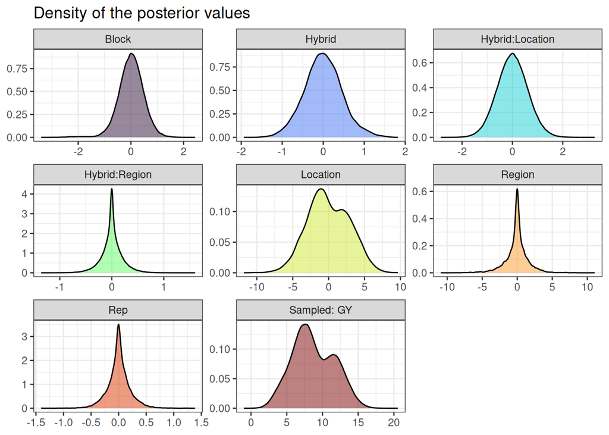

Posterior distributions of the model effects

```r
plot(outs, category = "density")
```

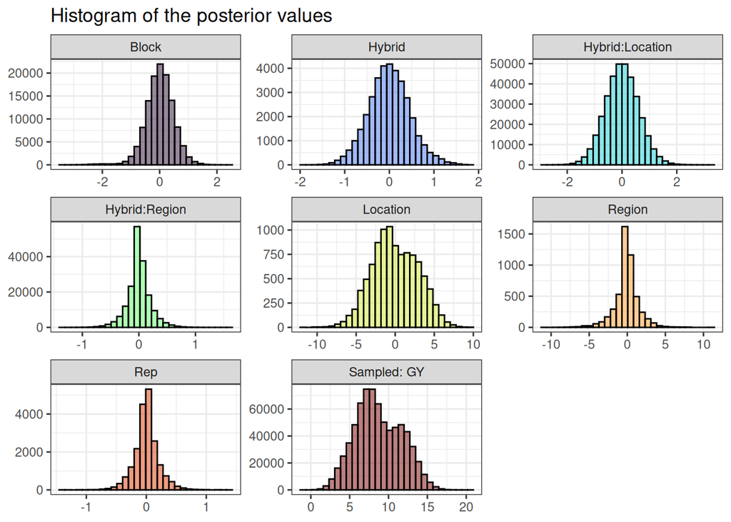

Posterior distributions of the model effects (histograms)

```r
plot(outs, category = "histogram")
```

The most important diagnostic plot compares the **empirical** phenotypic distribution to phenotypes **simulated** from the fitted model — the more the two densities overlap, the better the model captures the real data:

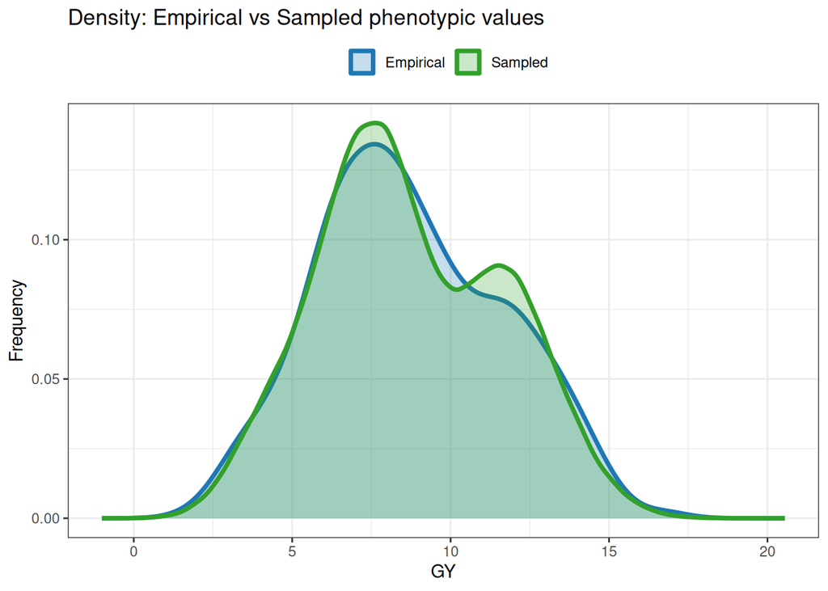

Empirical vs. model-simulated phenotype distributions

```r
plot(outs)
```

**Tip**

If `bayes_met()` raised convergence warnings but these diagnostics look reasonable (Bayesian p-values away from the extremes, $\hat{R}$ close to 1, strong empirical/simulated overlap), it is generally safe to proceed to Step 3.

# 6 Step 3 — Compute the Probabilities

This is where the probabilistic framework pays off. `prob_sup()` takes the extracted posterior (`outs`) and a **selection intensity** and returns every probability discussed in the theory talk.

```r
results <- prob_sup(
  extr     = outs,
  int      = 0.2,     # selection intensity: top 20% of genotypes
  increase = TRUE,    # we want to INCREASE grain yield (use FALSE for traits like disease severity)
  save.df  = FALSE,   # set TRUE to also write the probability tables to the working directory as .csv
  verbose  = FALSE
)
```

The result, `results`, is a `probsup` object containing two lists:

- `results$across` — probabilities computed **across** environments (general adaptability)
- `results$within` — probabilities computed **within** individual environments (local recommendation)

We will explore both.

## 6.1 Across-environment results

### 6.1.1 Posterior genotypic effects (HPD)

The highest posterior density (HPD) interval of each genotype’s main effect gives us a first, uncertainty-aware overview of performance:

```r
head(results$across$g_hpd)
```

|  | gen | g | HPD95 | HPD97.5 | HPD5 | HPD7.5 |
| --- | --- | --- | --- | --- | --- | --- |
| 1 | G1 | 0.7467114 | 1.2128062 | 1.31113852 | 0.28624724 | 0.1922964 |
| 2 | G10 | -0.5673370 | -0.1138294 | -0.05207921 | -1.03118589 | -1.1168312 |
| 3 | G11 | -0.1391469 | 0.3316289 | 0.41129032 | -0.58704189 | -0.6485908 |
| 4 | G12 | 0.1948202 | 0.6592362 | 0.74506601 | -0.22835262 | -0.3081656 |
| 5 | G13 | 0.4141475 | 0.8588056 | 0.96532055 | -0.01681442 | -0.1191833 |
| 6 | G14 | -0.2441677 | 0.2048437 | 0.30703511 | -0.69532949 | -0.7825561 |

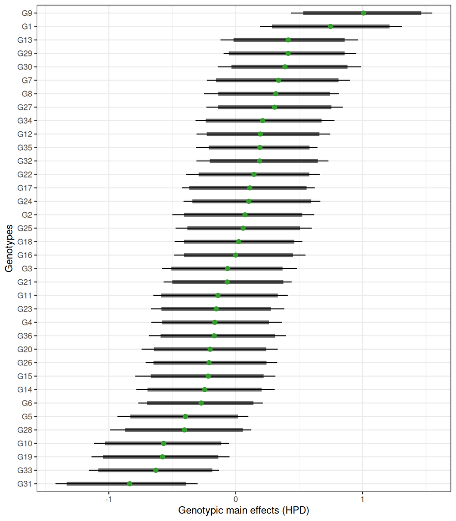

Caterpillar plot of the posterior genotypic main effects (HPD intervals)

```r
plot(results, category = "hpd")
```

Genotypes are sorted by their posterior mean; the interval width reflects how uncertain that estimate still is — useful context before we collapse everything into a single probability.

### 6.1.2 Probability of superior performance

```r
head(results$across$perfo)
```

|  | ID | prob |
| --- | --- | --- |
| 36 | G9 | 0.997 |
| 1 | G1 | 0.948 |
| 22 | G29 | 0.646 |
| 5 | G13 | 0.640 |
| 24 | G30 | 0.609 |
| 34 | G7 | 0.508 |

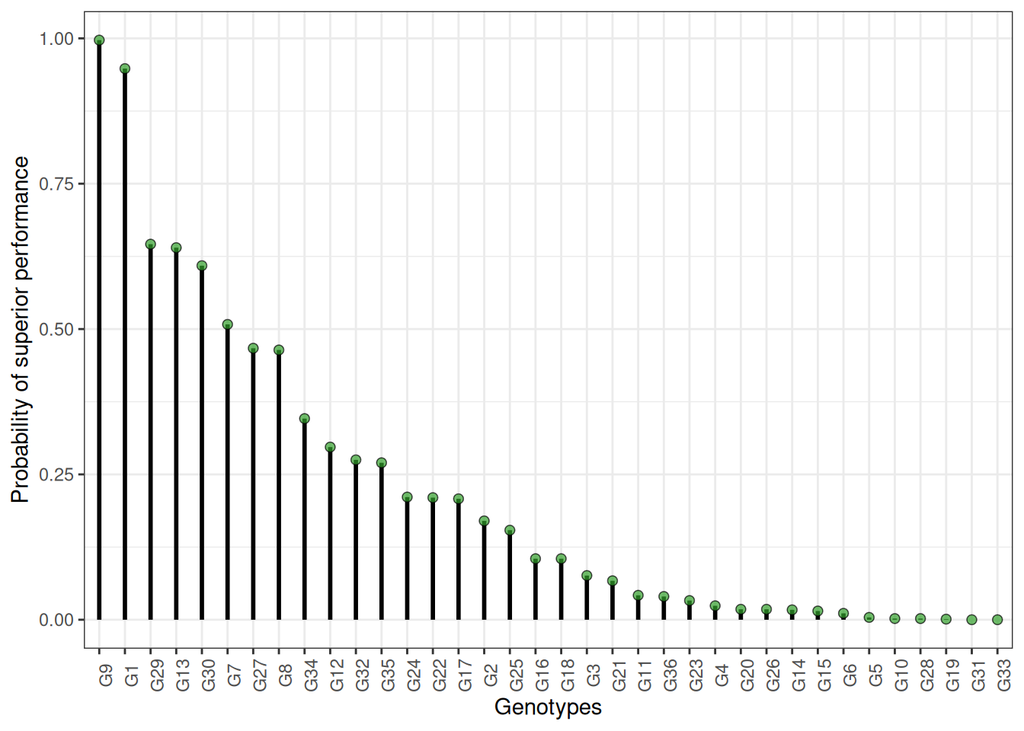

Probability of superior performance across environments

```r
plot(results)
```

This ranks genotypes by their probability of belonging to the top 20% (our chosen `int`) across the whole trial network — directly answering *“how much can I trust this genotype’s overall performance?”*

### 6.1.3 Pairwise probability of superior performance

Suppose one of the experimental hybrids is a promising candidate, and we want to know whether it truly outperforms a commercial check. Pick two genotype IDs present in your `results$across$perfo` table (adjust the codes below to genotypes from your own run) and compare them directly:

```r
# Full pairwise matrix (probability of the row-genotype's column exceeding
# every other genotype)
results$across$pair_perfo[1:5, 1:5]
```

```
       G1   G10   G11   G12   G13
G1  0.000 0.002 0.012 0.065 0.169
G10 0.998 0.000 0.872 0.979 0.993
G11 0.988 0.128 0.000 0.815 0.923
G12 0.935 0.021 0.185 0.000 0.720
G13 0.831 0.007 0.077 0.280 0.000
```

```r
# Direct query: replace "G1" and "G2" with an experimental hybrid and a
# commercial check from your own `maize` run
# results$across$pair_perfo["G1", "G2"]
```

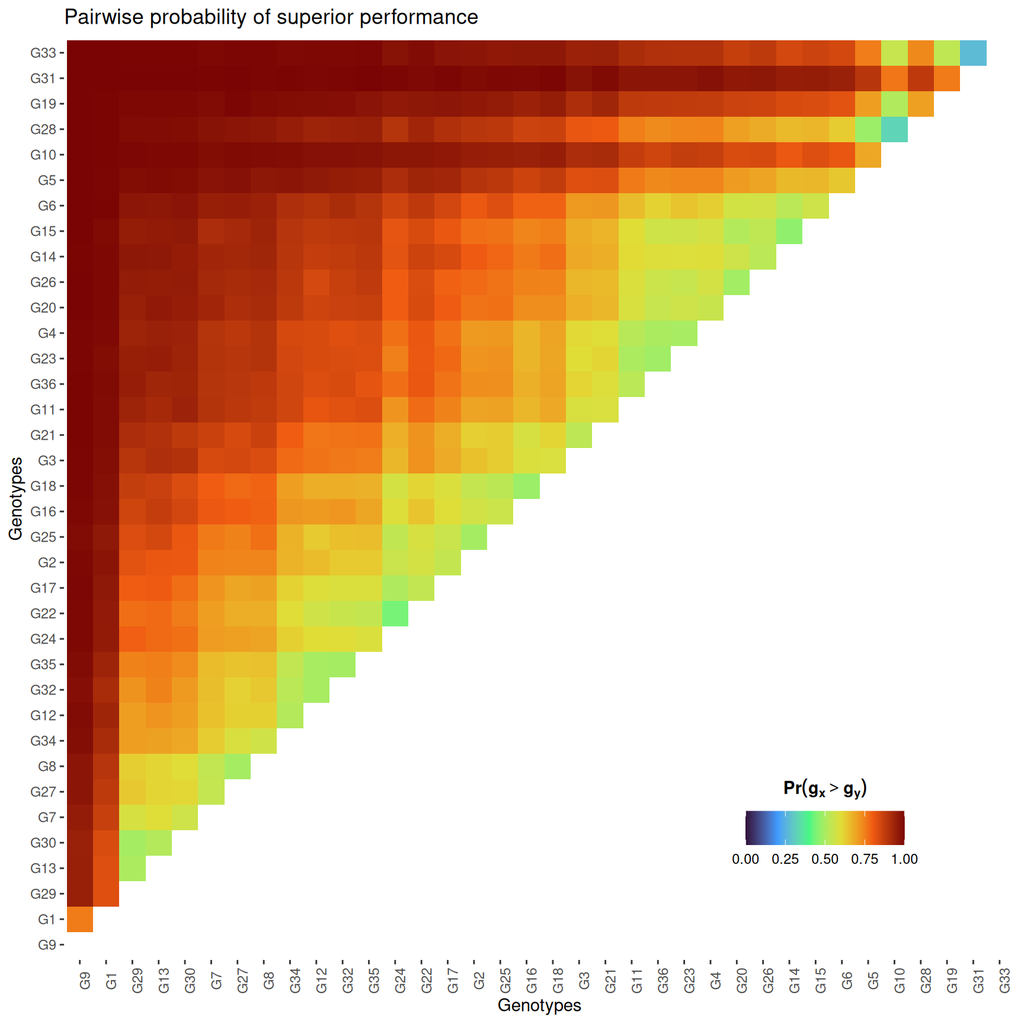

Heatmap of pairwise probabilities of superior performance

```r
plot(results, category = "pair_perfo")
```

Reading the heatmap: a cell’s color is the probability that the genotype on the **x-axis** outperforms the genotype on the **y-axis**.

### 6.1.4 Probability of superior stability

Recall from the theory talk: stability here means a *low* genotype-by-environment interaction variance. `ProbBreed` reports this both at the location level (`gl`) and the region level (`gm`):

```r
head(results$across$stabi$gl)  # stability across locations
```

|  | ID | prob |
| --- | --- | --- |
| 8 | G16 | 0.433 |
| 23 | G3 | 0.431 |
| 24 | G30 | 0.420 |
| 28 | G34 | 0.391 |
| 32 | G5 | 0.391 |
| 25 | G31 | 0.390 |

```r
head(results$across$stabi$gm)  # stability across regions
```

|  | ID | prob |
| --- | --- | --- |
| 1 | G1 | 0.270 |
| 10 | G18 | 0.270 |
| 17 | G24 | 0.250 |
| 13 | G20 | 0.246 |
| 24 | G30 | 0.245 |
| 32 | G5 | 0.245 |

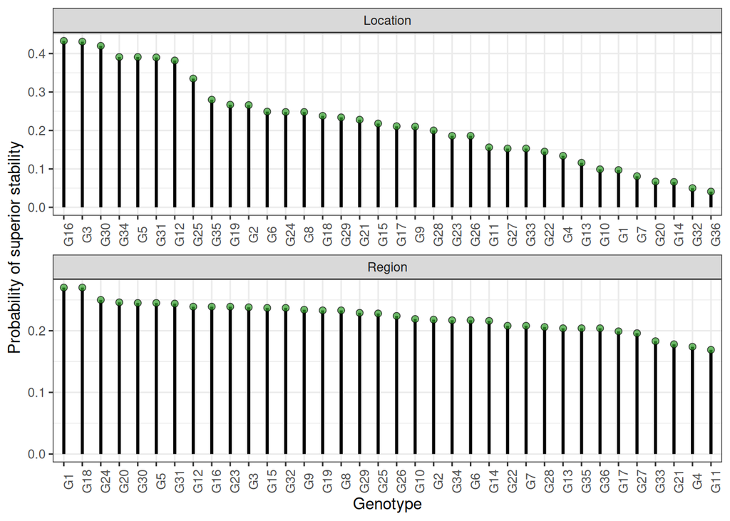

Probability of superior stability (location and region levels)

```r
plot(results, category = "stabi")
```

### 6.1.5 Pairwise probability of superior stability

```r
results$across$pair_stabi$gl[1:5, 1:5]  # location-level pairwise stability
```

```
       G1   G10   G11   G12   G13
G1  0.000 0.521 0.585 0.769 0.547
G10 0.479 0.000 0.545 0.746 0.515
G11 0.415 0.455 0.000 0.701 0.459
G12 0.231 0.254 0.299 0.000 0.259
G13 0.453 0.485 0.541 0.741 0.000
```

```r
results$across$pair_stabi$gm[1:5, 1:5]  # region-level pairwise stability
```

```
       G1   G10   G11   G12   G13
G1  0.000 0.458 0.425 0.480 0.442
G10 0.542 0.000 0.456 0.520 0.495
G11 0.575 0.544 0.000 0.560 0.516
G12 0.520 0.480 0.440 0.000 0.471
G13 0.558 0.505 0.484 0.529 0.000
```

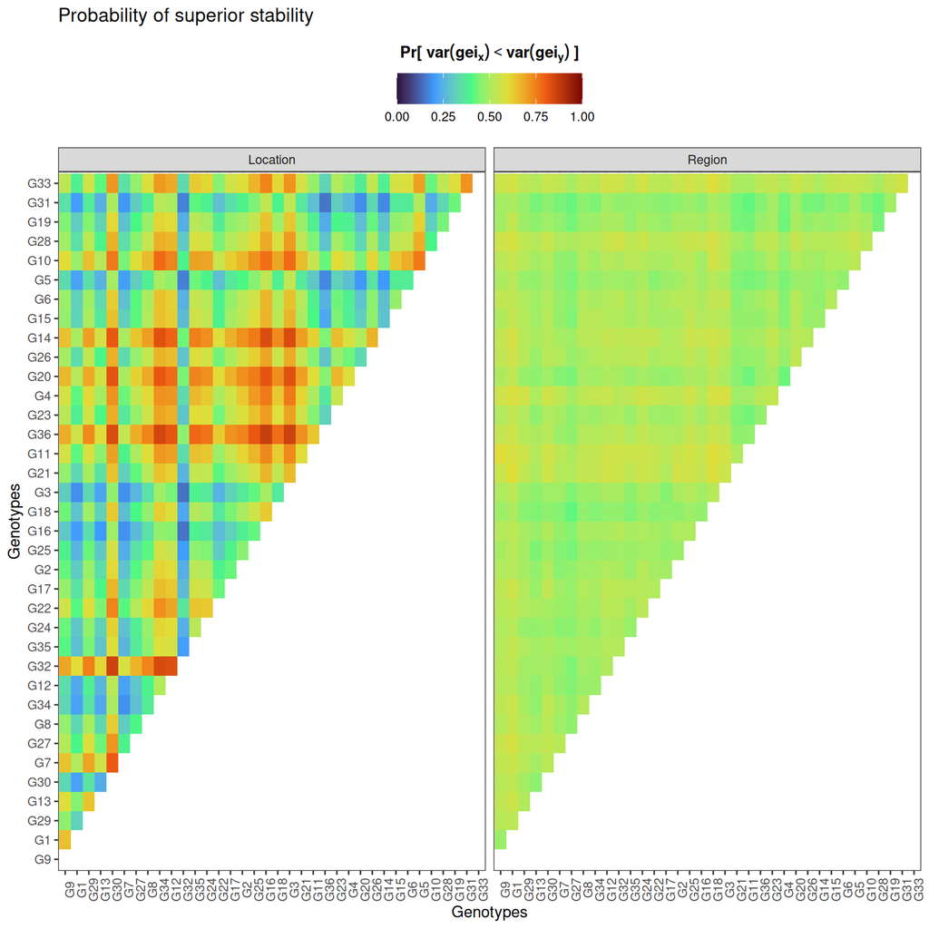

Heatmap of pairwise probabilities of superior stability

```r
plot(results, category = "pair_stabi")
```

### 6.1.6 Joint probability of superior performance and stability

The metric that usually matters most for a final recommendation call — a genotype that is simultaneously high-performing **and** dependable:

```r
head(results$across$joint)
```

|  | ID | level | category | prob |
| --- | --- | --- | --- | --- |
| 145 | G1 | Location | Joint | 0.091956 |
| 146 | G10 | Location | Joint | 0.000198 |
| 147 | G11 | Location | Joint | 0.006552 |
| 148 | G12 | Location | Joint | 0.113454 |
| 149 | G13 | Location | Joint | 0.074240 |
| 150 | G14 | Location | Joint | 0.001122 |

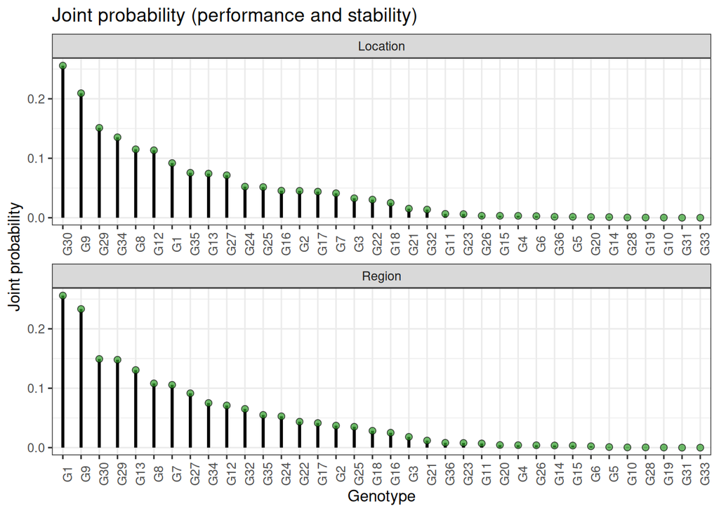

Joint probability of superior performance and stability

```r
plot(results, category = "joint")
```

**ImportantDiscussion prompt**

Look at the genotype that ranks #1 in `perfo` (raw performance). Does it also rank #1 in `joint`? If not, why might that be — and which genotype would *you* recommend to a grower, and why?

## 6.2 Within-environment results

Across-environment probabilities describe general adaptability. But breeders often need **local** recommendations for a specific location or region. That is what `results$within` provides.

### 6.2.1 Probability of superior performance within environments

```r
head(results$within$perfo$gl)  # within-location
```

|  | gen | E1 | E10 | E12 | E15 | E16 | E3 | E4 | E5 | E6 | E8 |
| --- | --- | --- | --- | --- | --- | --- | --- | --- | --- | --- | --- |
| 1 | G1 | 0.969 | 0.365 | 0.516 | 0.304 | 0.974 | 0.628 | 0.936 | 0.571 | 0.449 | 0.925 |
| 2 | G10 | 0.011 | 0.001 | 0.006 | 0.000 | 0.031 | 0.135 | 0.001 | 0.040 | 0.020 | 0.000 |
| 3 | G11 | 0.004 | 0.089 | 0.004 | 0.698 | 0.076 | 0.027 | 0.013 | 0.103 | 0.317 | 0.047 |
| 4 | G12 | 0.151 | 0.116 | 0.061 | 0.155 | 0.552 | 0.550 | 0.174 | 0.344 | 0.336 | 0.104 |
| 5 | G13 | 0.243 | 0.268 | 0.173 | 0.803 | 0.084 | 0.718 | 0.715 | 0.624 | 0.822 | 0.123 |
| 6 | G14 | 0.000 | 0.004 | 0.161 | 0.001 | 0.025 | 0.065 | 0.122 | 0.126 | 0.636 | 0.045 |

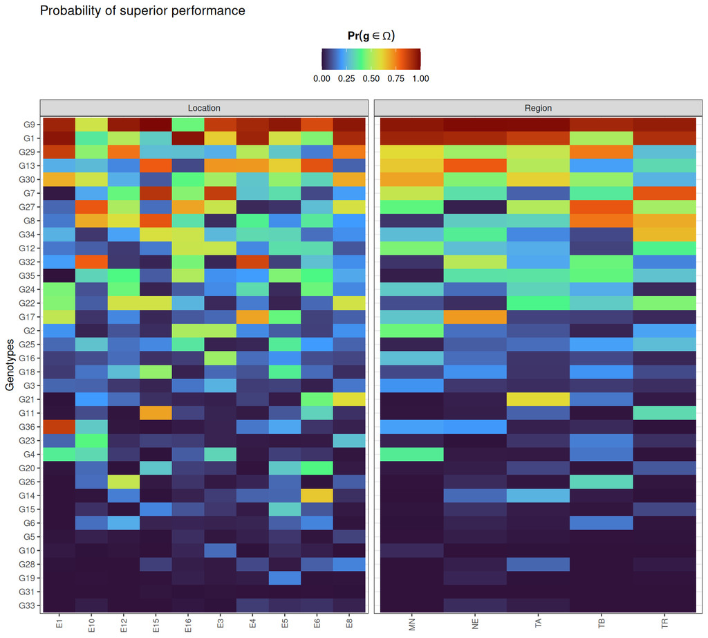

Heatmap of within-environment probabilities of superior performance

```r
plot(results, category = "perfo", level = "within")
```

### 6.2.2 Pairwise probability of superior performance within environments

Because this comparison is specific to each environment, `plot()` returns a **list of plots** (one per location/region) rather than a single figure. Store it in an object before plotting:

```r
pairsupwithin <- plot(results, category = "pair_perfo", level = "within")

# Example: inspect a single location or region
pairsupwithin$gl$E1   # pairwise comparisons within location "E1"
pairsupwithin$gm$R1   # pairwise comparisons within region "R1"
```

**Note**

Substitute `"E1"`/`"R1"` above with the actual location/region codes present in your fitted `maize` model (check `levels(factor(maize$Location))` and `levels(factor(maize$Region))`).

# 7 Wrap-Up: The Questions We Can Now Answer

Having walked through the full pipeline, we are equipped to answer exactly the kind of questions that motivate cultivar recommendation in practice:

1. What is the **risk** of recommending a given selection candidate?
2. What is the **probability** that a candidate performs well across — or within — environments?
3. Is a candidate genotype **better than a commercial check**, and with what confidence?
4. How likely is a genotype to perform **similarly** across the target population of environments?
5. Is a candidate **more stable** than the check cultivar?
6. Which genotype has both **superior and dependable** performance across environments?

# 8 Practice Exercise

Now it’s your turn. Using the fitted `results` object:

1. Identify the genotype with the highest **joint** probability across **regions** (`results$across$joint`, filtered to `level == "Region"`).
2. Pick any commercial check in the `maize` data and find the experimental hybrid most likely to outperform it, using `results$across$pair_perfo`.
3. Re-run Step 3 with `int = 0.1` (a stricter, top-10% selection intensity). How much does the ranking in `results$across$perfo` change?

```r
# Your code here
```

# 9 References

- Chaves, S. F. S., Krause, M. D., Dias, L. A. S., Garcia, A. A. F., & Dias, K. O. G. (2024). ProbBreed: a novel tool for calculating the risk of cultivar recommendation in multienvironment trials. *G3: Genes|Genomes|Genetics*, 14(3), jkae013. https://doi.org/10.1093/g3journal/jkae013
- Dias, K. O. G., Santos, J. P. R., Krause, M. D., Piepho, H.-P., Guimarães, L. J. M., Pastina, M. M., & Garcia, A. A. F. (2022). Leveraging probability concepts for cultivar recommendation in multi-environment trials. *Theoretical and Applied Genetics*, 135(4), 1385–1399. https://doi.org/10.1007/s00122-022-04041-y
- Package documentation: https://saulo-chaves.github.io/ProbBreed_site/
- Source code: https://github.com/saulo-chaves/ProbBreed